# Test of permutation t test type I error rates through simulation

John Willoughby

2025-01-17

This paper examines, through simulations, how well a two-sample permutation t test (also called a randomization t test) approximates the desired Type I error specified in the test. The permutation t test uses the same t statistic as the independent-sample t test, but obtains a p value from the permutation distribution of the t statistic, instead of using the theoretical distribution derived from the parametric assumption. Two advantages of this approach are: 1) it is likely to be more robust than the independent-sample t test in situations where the assumption of normality is violated, and 2) unlike a traditional permutation test, it can employ a Welch t test, which allows for variances to be unequal. A separate report shows that type I error rates for the traditional permutation test are not sufficiently robust when both sample sizes and variances differ.

The results for equal and unequal sample sizes and equal and unequal variances are examined, both for normal and skewed distributions.

In each of the situations examined, both samples come from the same population, so any p values less than the specified alpha value represent Type I errors (often called false-change errors in a monitoring context).

Bradley (1978) provided a quantified measure of robustness. His criterion for a “neglible” departure of the realized type I error rate from the desired alpha was that it should fall within the interval 0.9*alpha to 1.1*alpha, meaning that for a desired alpha of 0.05, the realized type I error rate should be inside the interval 0.045 to 0.055. For a desired alpha of 0.10, the realized type I error rate should be inside the interval 0.09 to 0.11. His “liberal” criterion for robustness specified that the realized Type 1 error rate should fall within the interval 0.5*alpha to 1.5*alpha. So if the specified alpha is 0.05, then the realized Type 1 error rate should be inside the interval 0.025 to 0.075. If the specified alpha is 0.10, then the realized Type I error rate should fall within the interval 0.05 to 0.15. We will look only at alpha = 0.05 here, but you can change the alpha level in the code below to examine what would happen with different alpha values.

Load needed packages:

```r
library(tidyverse) # Loads ggplot, dplyr, and several other packages.
library(flextable) # To make tables
library(fGarch) # To create skewed normal random values
library(MKinfer) # To perform the permutation t test
```

Let’s examine 24 different several sampling scenarios. We’ll first use the standard normal distribution, which has a mean of 0 and a standard deviation of 1 and then alter the sample size and increase the standard deviation of one or both of the samples to 2. Later below we’ll use a right-skewed normal distribution with a mean of 0 and standard deviations of 1 or 2.

In each of these scenarios both samples have the same mean, so we’re essentially assuming that the two samples come from a population with a mean of zero; thus we’re examining the null distribution for a population with a mean of zero. This means that when we run a t test on these samples and set the desired alpha to 0.05, just by chance about 5% of the p values should fall below 0.05. These are type I errors.

We’ll set the number of simulations to 1000 for each comparison, but this can be changed in the code below. Because the permutation test itself uses many permutations, the code can take a long time to run if simulations are set higher. With 1000 simulations and 1000 permutations for each permutation t test, the code below takes about 48 minutes to run.

Note that I am not setting a random number seed for these simulations, so if you run the simulations you will get somewhat different results.

The following combinations of n1 size, n2 size, and sample standard deviations (s1 and s2) are run (means are 0 in all cases):

| n1 | n2 | s1 | s1 |
| --- | --- | --- | --- |
| 10 | 10 | 1 | 1 |
| 10 | 10 | 1 | 2 |
| 10 | 10 | 2 | 2 |
| 10 | 20 | 1 | 1 |
| 20 | 10 | 1 | 1 |
| 10 | 20 | 1 | 2 |
| 20 | 10 | 1 | 2 |
| 30 | 30 | 1 | 1 |
| 30 | 30 | 1 | 2 |
| 30 | 30 | 2 | 2 |
| 30 | 30 | 2 | 1 |
| 30 | 50 | 1 | 1 |
| 50 | 30 | 1 | 1 |
| 30 | 50 | 1 | 2 |
| 50 | 30 | 1 | 2 |
| 50 | 50 | 1 | 1 |
| 50 | 50 | 1 | 2 |
| 50 | 50 | 2 | 1 |
| 100 | 100 | 1 | 1 |
| 100 | 100 | 1 | 2 |
| 100 | 100 | 2 | 1 |
| 100 | 50 | 1 | 1 |
| 100 | 50 | 1 | 2 |
| 50 | 100 | 1 | 2 |

Set the number of simulations to run.

```r
nreps = 1000
```

Set the alpha level

```r
alpha.p = 0.05
```

### Permutation t tests on samples from normal populations

Create a data frame with combinations of sample sizes and standard deviations for the two samples, n1 and n2. Standard deviations for each sample are specified in columns s1 and s2. Add columns p.var.equal and p.var.unequal and fill with NA. The mean type I error values for these columns will be filled in by the pmap_dbl() function below.

```r
combos = data.frame(n1 = c(10, 10, 10, 10, 20, 10, 20, 30,
                           30, 30, 30, 30, 50, 30, 50, 50,
                           50, 50, 100, 100, 100, 100,
                           100, 50),
                    n2 = c(10, 10, 10, 20, 10, 20, 10, 30,
                           30, 30, 30, 50, 30, 50, 30, 50,
                           50, 50, 100, 100, 100, 50, 50, 100),
                    s1 = c(1, 1, 2, 1, 1, 1, 1, 1, 1, 2, 2,
                           1, 1, 1, 1, 1, 1, 2, 1, 1, 2, 1,
                           1, 1),
                    s2 = c(1, 2, 2, 1, 1, 2, 2, 1, 2, 2, 1,
                           1, 1, 2, 2, 1, 2, 1, 1, 2, 1, 1,
                           2, 2),
                    p.var.equal = rep(NA, 24),
                    p.var.unequal = rep(NA, 24))


combos2 = combos  # Create a second combos df for later analysis on skewed data.
```

The pmap_dbl() function below takes the sample sizes and standard deviations in each row of the combos data frame created above, draws two random samples from the same populations, performs a permutation t test on each pair of samples and records the p value for the test. It does this the number of times specified in nreps above, and returns the mean proportion of times the p values fell below the alpha level specified (0.05 as entered above). This is the empirical type I error rate for each of the 24 sampling scenarios.

```r
combos$p.var.equal = pmap_dbl(
   .l = list(combos$n1,
    combos$n2,
    combos$s1,
    combos$s2),
   \(n1, n2, s1, s2) mean(replicate(nreps,
                       perm.t.test(rnorm(n1, mean = 0, sd = s1),
                       rnorm(n2, mean = 0, sd = s2), alternative = "two.sided",
                       R = 999, var.equal = TRUE)$p.value) < 0.05)
)

combos$p.var.unequal = pmap_dbl(
   .l = list(combos$n1,
    combos$n2,
    combos$s1,
    combos$s2),
   \(n1, n2, s1, s2) mean(replicate(nreps,
                       perm.t.test(rnorm(n1, mean = 0, sd = s1),
                       rnorm(n2, mean = 0, sd = s2), alternative = "two.sided",
                       R = 999, var.equal = FALSE)$p.value) < 0.05)
)
```

Put the results in a table.

```r
ft1 = flextable(combos)


ft1 = set_caption(ft1,
                 caption = paste0("Empirical type I error rates from ", nreps, " simulations of permutation t tests on samples from a normal population with a mean of 0 and equal or unequal standard deviations with various equal or unequal sample sizes. The target alpha value is ", alpha.p," and permutation t tests were run assuming equal or unequal variance. ")) |>
  set_header_labels(ft1, p.var.equal = "Type I error from equal variance permutation t test", p.var.unequal = "Type I error from unequal variance permutation t test")
ft1
```

Empirical type I error rates from 1000 simulations of permutation t tests on samples from a normal population with a mean of 0 and equal or unequal standard deviations with various equal or unequal sample sizes. The target alpha value is 0.05 and permutation t tests were run assuming equal or unequal variance.

| n1 | n2 | s1 | s2 | Type I error from equal variance permutation t test | Type I error from unequal variance permutation t test |
| --- | --- | --- | --- | --- | --- |
| 10 | 10 | 1 | 1 | 0.043 | 0.047 |
| 10 | 10 | 1 | 2 | 0.043 | 0.040 |
| 10 | 10 | 2 | 2 | 0.052 | 0.060 |
| 10 | 20 | 1 | 1 | 0.064 | 0.046 |
| 20 | 10 | 1 | 1 | 0.051 | 0.056 |
| 10 | 20 | 1 | 2 | 0.012 | 0.045 |
| 20 | 10 | 1 | 2 | 0.116 | 0.062 |
| 30 | 30 | 1 | 1 | 0.054 | 0.044 |
| 30 | 30 | 1 | 2 | 0.053 | 0.049 |
| 30 | 30 | 2 | 2 | 0.050 | 0.058 |
| 30 | 30 | 2 | 1 | 0.053 | 0.058 |
| 30 | 50 | 1 | 1 | 0.045 | 0.049 |
| 50 | 30 | 1 | 1 | 0.062 | 0.054 |
| 30 | 50 | 1 | 2 | 0.031 | 0.047 |
| 50 | 30 | 1 | 2 | 0.079 | 0.050 |
| 50 | 50 | 1 | 1 | 0.041 | 0.035 |
| 50 | 50 | 1 | 2 | 0.054 | 0.054 |
| 50 | 50 | 2 | 1 | 0.053 | 0.059 |
| 100 | 100 | 1 | 1 | 0.047 | 0.069 |
| 100 | 100 | 1 | 2 | 0.035 | 0.044 |
| 100 | 100 | 2 | 1 | 0.044 | 0.043 |
| 100 | 50 | 1 | 1 | 0.040 | 0.043 |
| 100 | 50 | 1 | 2 | 0.114 | 0.052 |
| 50 | 100 | 1 | 2 | 0.012 | 0.059 |

The p values from the permutation t test allowing for unequal variance are all reasonably close to the desired alpha of 0.05 for all scenarios. The p values from the permutation t test assuming equal variance are sufficiently close to 0.05 even when variances differ *as long as the sample sizes are the same*. When both sample sizes and variances differ, the p values from the equal variance permutation t test are too different from the desired alpha: too large when the smaller sample has the larger variance and too small when the larger sample has the larger variance.

### Permuation t tests on samples from a right-skewed normal population

Now we’ll do the same analysis except the samples come from a right-skewed normal population. The mean is still zero and the standard deviation is either 1 or 2. But now there’s a skewness parameter (xi) that skews the population to the right. Here are examples of populations with this skew, one with a standard deviation of 1 and the other with a standard deviation of 2.

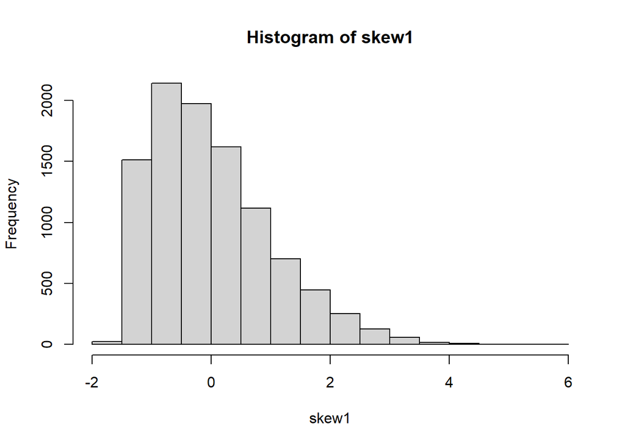

```r
skew1 = rsnorm(10000, mean = 0, sd = 1, xi = 3)
skew2 = rsnorm(10000, mean = 0, sd = 2, xi = 3)
hist(skew1)
```

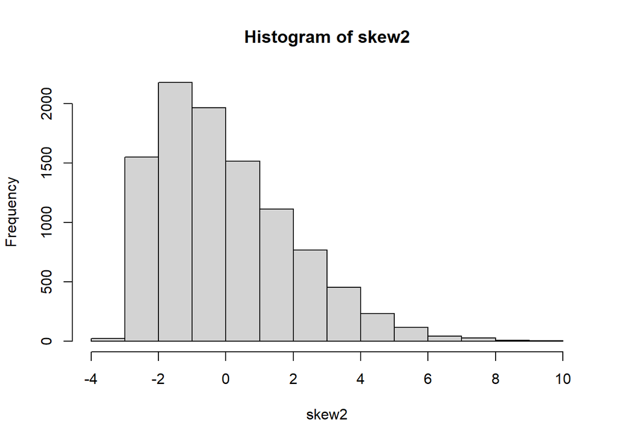

```r
hist(skew2)
```

Run the simulations using the skewed normal distribution and put the results in the combos2 dataframe we created above.

```r
combos2$p.var.equal = pmap_dbl(
    .l = list(combos$n1,
              combos$n2,
              combos$s1,
              combos$s2),
    \(n1, n2, s1, s2) mean(replicate(nreps,
                         perm.t.test(rsnorm(n1, mean = 0, sd = s1, xi = 3),
                         rsnorm(n2, mean = 0, sd = s2, xi = 3),
                         alternative = "two.sided", R = 999,
                         var.equal = TRUE)$p.value) < 0.05)
)

combos2$p.var.unequal = pmap_dbl(
    .l = list(combos$n1,
              combos$n2,
              combos$s1,
              combos$s2),
    \(n1, n2, s1, s2) mean(replicate(nreps,
                         perm.t.test(rsnorm(n1, mean = 0, sd = s1, xi = 3),
                         rsnorm(n2, mean = 0, sd = s2, xi = 3),
                         alternative = "two.sided", R = 999,
                         var.equal = FALSE)$p.value) < 0.05)
)
```

Put the results in a table.

```r
ft2 = flextable(combos2)


ft2 = set_caption(ft2,
                 caption = paste0("Empirical type I error rates from ", nreps, " simulations of permutation t tests on samples from a right-skewed normal population with a mean of 0 and equal or unequal standard deviations with various equal or unequal sample sizes. The target alpha value is ", alpha.p," and permutation t tests were run  assuming equal or unequal variance. ")) |>
  set_header_labels(ft1, p.var.equal = "Type I error from equal variance permutation t test", p.var.unequal = "Type I error from unequal variance permutation t test")
ft2
```

Empirical type I error rates from 1000 simulations of permutation t tests on samples from a right-skewed normal population with a mean of 0 and equal or unequal standard deviations with various equal or unequal sample sizes. The target alpha value is 0.05 and permutation t tests were run assuming equal or unequal variance.

| n1 | n2 | s1 | s2 | Type I error from equal variance permutation t test | Type I error from unequal variance permutation t test |
| --- | --- | --- | --- | --- | --- |
| 10 | 10 | 1 | 1 | 0.043 | 0.046 |
| 10 | 10 | 1 | 2 | 0.064 | 0.059 |
| 10 | 10 | 2 | 2 | 0.049 | 0.055 |
| 10 | 20 | 1 | 1 | 0.043 | 0.053 |
| 20 | 10 | 1 | 1 | 0.052 | 0.074 |
| 10 | 20 | 1 | 2 | 0.033 | 0.073 |
| 20 | 10 | 1 | 2 | 0.105 | 0.063 |
| 30 | 30 | 1 | 1 | 0.055 | 0.036 |
| 30 | 30 | 1 | 2 | 0.058 | 0.048 |
| 30 | 30 | 2 | 2 | 0.045 | 0.040 |
| 30 | 30 | 2 | 1 | 0.052 | 0.056 |
| 30 | 50 | 1 | 1 | 0.032 | 0.048 |
| 50 | 30 | 1 | 1 | 0.044 | 0.058 |
| 30 | 50 | 1 | 2 | 0.023 | 0.056 |
| 50 | 30 | 1 | 2 | 0.085 | 0.055 |
| 50 | 50 | 1 | 1 | 0.056 | 0.065 |
| 50 | 50 | 1 | 2 | 0.062 | 0.047 |
| 50 | 50 | 2 | 1 | 0.041 | 0.050 |
| 100 | 100 | 1 | 1 | 0.046 | 0.053 |
| 100 | 100 | 1 | 2 | 0.055 | 0.047 |
| 100 | 100 | 2 | 1 | 0.043 | 0.049 |
| 100 | 50 | 1 | 1 | 0.052 | 0.048 |
| 100 | 50 | 1 | 2 | 0.118 | 0.049 |
| 50 | 100 | 1 | 2 | 0.014 | 0.047 |

As with the normally distributed samples, the p values from the unequal variance permutation t test are sufficiently close to 0.05 for all sampling scenarios. With the equal variance permutation t test, the same pattern is observed as for the normally distributed samples: when variances and sample sizes differ, the p value is too low when the larger variance is associated with the larger sample and too high when the larger variance is associated with the smaller sample.

### Literature Cited

Bradley, James V. 1978. “Robustness?” *British Journal of Mathematical and Statistical Psychology* 31 (2): 144–52. https://doi.org/10.1111/j.2044-8317.1978.tb00581.x.